# AR and MA analysis with Python

###### By Rohit Pardasani

```python
import statsmodels.tsa.stattools as ts
import numpy as np
import pandas as pd
```

### MA(q) process

First decide a MA(q) process and simulate it using the statsmodels  
Let's take $X_t = Z_t + 0.7Z_{t-1} + 0.5Z_{t-2}$  
Implies this is MA(2) process ($X_t = Z_t + \beta_1Z_{t-1} + \beta_2Z_{t-2}$, with $\beta_1=0.7$ and $\beta_2=0.5$)  
Is it invertible ?  
$X_t = Z_t + \beta_1Z_{t-1} + \beta_2Z_{t-2}$  
$X_t = (1 + \beta_1B + \beta_2B^2)Z_t$  
$X_t = \beta(B)Z_t$  
We should find roots of $\beta(B)$ and these should lie outside the unit circle for MA(2) to be invertible.

```python
import numpy as np
coeff = [0.5,0.7,1]
roots = np.roots(coeff)
print('Roots : ',roots)
print('Magnitude of Roots : ',[abs(roots[0]),abs(roots[1])])
print('This is MA process is invertible')
```

```
Roots :  [-0.7+1.22882057j -0.7-1.22882057j]
Magnitude of Roots :  [1.414213562373095, 1.414213562373095]
This is MA process is invertible
```

ARMA simulator in statsmodels takes arguments ar and ma  
The conventions of the arma_generate function require that we specify a 1 for the zero-lag of the AR and MA parameters and that the AR parameters be negated.  
For example: if ARMA process is given by

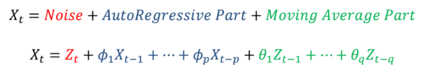

Then ar = $[1,-\phi_1,-\phi_2,-\phi_3,....]$  
and ma = $[1,\theta_1,\theta_2,\theta_3,....]$

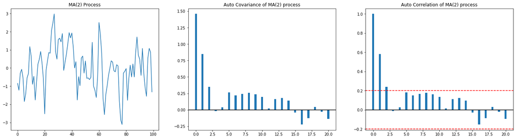

```python
import matplotlib.pyplot as plt
from statsmodels.tsa import arima_process
ma_params = [1,0.7,0.5]
ar_params = [1]
x = arima_process.arma_generate_sample(ar=ar_params,ma=ma_params,nsample=100)
plt.figure(figsize=(24,6))
plt.subplot(1,3,1)
plt.title("MA(2) Process")
plt.plot(x)

plt.subplot(1,3,2)
acovf_x = ts.acovf(x,fft=False,adjusted=False,nlag=20)
plt.bar(x=np.arange(len(acovf_x)),height=acovf_x,width=0.3)
plt.axhline(y=0,color='black')
plt.title("Auto Covariance of MA(2) process")

plt.subplot(1,3,3)
acorf_x = ts.acf(x,fft=False,adjusted=False,nlags=20)
plt.bar(x=np.arange(len(acorf_x)),height=acorf_x,width=0.3)
plt.axhline(y=0,color='black')
plt.axhline(y=0.2,color='red',linestyle='--')
plt.axhline(y=-0.2,color='red',linestyle='--')
plt.title("Auto Correlation of MA(2) process")
#plt.plot(x)
plt.show()
```

We know that:  
A moving average process of order q has an ACF that cuts off after q lags.  
And we see that ACF for MA(2) process cuts off after 2 lags.

```python
print(acorf_x[0:3])
```

```
[1.         0.58133506 0.23841373]
```

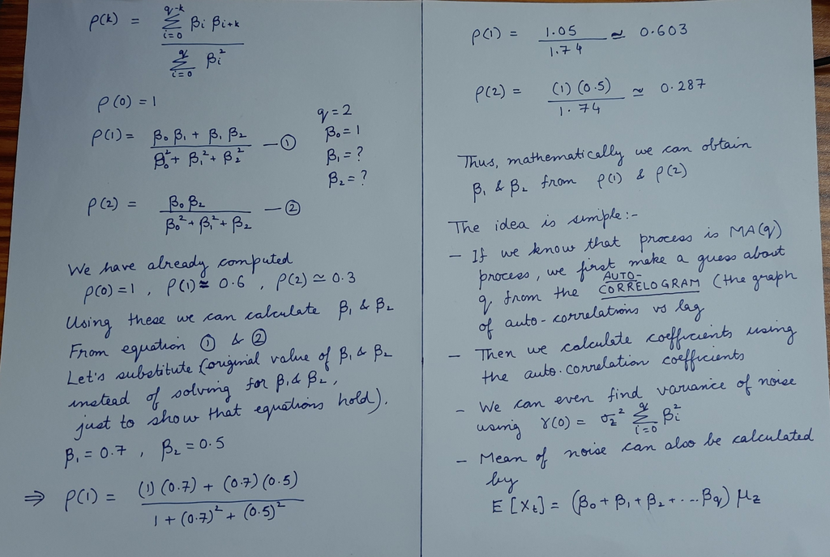

We can also solve this using statsmodels library  
statsmodels.tsa.arima.model.ARIMA(endog,order=(p,d,q))  
endog has the time series  
p,q = (0,0,2) for the above MA(2) process

```python
from statsmodels.tsa.arima.model import ARIMA
mod = ARIMA(endog=x, order=(0,0,2))
res = mod.fit()
print('Model Specification : ',res.specification,'\n')
print('Autoregression Coefficients : ',res.polynomial_ar,'\n')
print('Moving Average Coefficients : ',res.polynomial_ma,'\n')
print('AIC (Akaike information criterion) : ',res.aic,'\n')
```

```
Model Specification :  {'seasonal_periods': 0, 'measurement_error': False, 'time_varying_regression': False, 'simple_differencing': False, 'enforce_stationarity': True, 'enforce_invertibility': True, 'hamilton_representation': False, 'concentrate_scale': False, 'trend_offset': 1, 'order': (0, 0, 2),…

Autoregression Coefficients :  [1.]

Moving Average Coefficients :  [1.         0.63089984 0.55626076]

AIC (Akaike information criterion) :  276.81163459696126
```

### AR(p) process

First decide a AR(p) process and simulate it using the statsmodels  
Let's take $X_t = Z_t + 0.6X_{t-1} + 0.3X_{t-2}$  
Implies this is AR(2) process ($X_t = Z_t + \phi_1X_{t-1} + \phi_2X_{t-2}$, with $\phi_1=0.6$ and $\phi_2=0.3$)  
Is it stationary ?  
$X_t - \phi_1X_{t-1} - \phi_2X_{t-2}= Z_t$  
$(1 - \phi_1B - \phi_2B^2)X_t = Z_t$  
$\phi(B)X_t = Z_t$  
We should find roots of $\phi(B)$ and these should lie outside the unit circle for AR(2) to be stationary.

```python
import numpy as np
coeff = [-0.3,-0.6,1]
roots = np.roots(coeff)
print('Roots : ',roots)
print('Magnitude of Roots : ',[abs(roots[0]),abs(roots[1])])
print('This is AR process is stationary')
```

```
Roots :  [-3.081666  1.081666]
Magnitude of Roots :  [3.081665999466133, 1.0816659994661326]
This is AR process is stationary
```

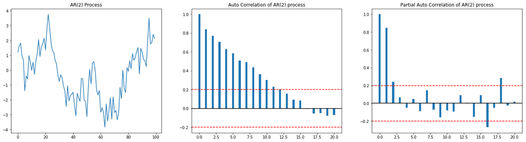

```python
import matplotlib.pyplot as plt
from statsmodels.tsa import arima_process
ar_params = [1,-0.6,-0.3]
ma_params = [1]
x = arima_process.arma_generate_sample(ar=ar_params,ma=ma_params,nsample=100)
plt.figure(figsize=(24,6))
plt.subplot(1,3,1)
plt.title("AR(2) Process")
plt.plot(x)

plt.subplot(1,3,2)
acorf_x = ts.acf(x,fft=False,adjusted=False,nlags=20)
plt.bar(x=np.arange(len(acorf_x)),height=acorf_x,width=0.3)
plt.axhline(y=0,color='black')
plt.axhline(y=0.2,color='red',linestyle='--')
plt.axhline(y=-0.2,color='red',linestyle='--')
plt.title("Auto Correlation of AR(2) process")

plt.subplot(1,3,3)
apcorf_x = ts.pacf(x,nlags=20)
plt.bar(x=np.arange(len(apcorf_x)),height=apcorf_x,width=0.3)
plt.axhline(y=0,color='black')
plt.axhline(y=0.2,color='red',linestyle='--')
plt.axhline(y=-0.2,color='red',linestyle='--')
plt.title("Partial Auto Correlation of AR(2) process")

#plt.plot(x)
plt.show()
```

We know that:  
An autoregressive process of order p, an AR(p), has a PACF that cuts off after p lags.  
And we see that PACF for AR(2) process cuts off after 2 lags.

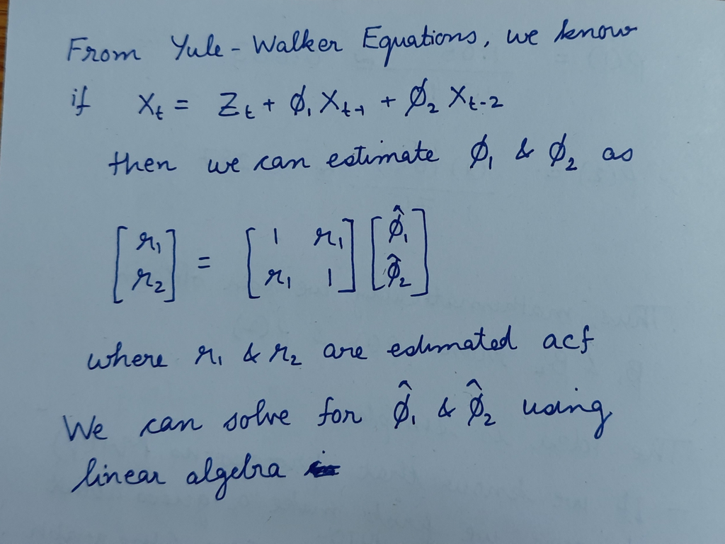

```python
print(acorf_x[0:3])
```

```
[1.         0.83983663 0.77137814]
```

```python
r1 = acorf_x[1]
r2 = acorf_x[2]
A = np.array([[1, r1], [r1, 1]])
b = np.array([r1, r2])
x = np.linalg.solve(A, b)
print(x)
print('which is close to actual values [0.6,0.3]')
```

```
[0.65158355 0.22415441]
which is close to actual values [0.6,0.3]
```

```python
from statsmodels.tsa.arima.model import ARIMA
mod = ARIMA(endog=x, order=(2,0,0),trend='n')
res = mod.fit()
print('Model Specification : ',res.specification,'\n')
print('Autoregression Coefficients : ',res.polynomial_ar,'\n')
print('Moving Average Coefficients : ',res.polynomial_ma,'\n')
print('AIC (Akaike information criterion) : ',res.aic,'\n')
```

```
Model Specification :  {'seasonal_periods': 0, 'measurement_error': False, 'time_varying_regression': False, 'simple_differencing': False, 'enforce_stationarity': True, 'enforce_invertibility': True, 'hamilton_representation': False, 'concentrate_scale': False, 'trend_offset': 1, 'order': (2, 0, 0),…

Autoregression Coefficients :  [ 1.00000000e+00 -6.15232343e-01 -2.24691951e-06]

Moving Average Coefficients :  [1.]

AIC (Akaike information criterion) :  8.32414952127492
```